# Lab 4: Tidy Data

Mario Giacomazzo

February 20, 2024

# Introduction

Baby Mario once had a dream to drop math knowledge on high school students. High schools are evaluated based on student achievement on standardized test scores. The self-proclaimed king, [Lebron James](http://lebronjames.com/), intends to donate $5 million to the district and funds will be distributed according to the improvement of these high schools in the area of mathematics. Because of the king’s proclamation, the bureaucratic district heads have pushed high schools to redirect all loose change to mathematics. Teachers of english, science, history, and other subjects have been pressured to dedicate portions of class time to math education. Teachers of music and the arts have been released because the king does not have time for that nonsense. The dreams of these children along with the king’s talents have been taken to Hollywood.

The [Cleveland school district](http://www.clevelandmetroschools.org/) is made up of 20 high schools uniquely identified by numbers 1 to 20. Within each high school, a random sample of 20 students are selected to participate in this study and are uniquely identified by numbers 1 to 20. All 400 students selected are assessed on their mathematics skills based on district designed standardized tests in the years 2017 and 2018. The scores and corresponding percentiles of these selected students for both years are simulated in the following R code.

```r
school.id=rep(1:20,each=20*2)
student.id=rep(rep(1:20,each=2),20)
type=rep(c("Score","Percentile"),20*20)
score2017=round(rnorm(20*20,mean=50,sd=10),0)
percentile2017=round(100*pnorm(score2017,mean=mean(score2017),sd=sd(score2017)),0)
score2018=round(rnorm(20*20,mean=75,sd=4),0)
percentile2018=round(100*pnorm(score2018,mean=mean(score2018),sd=sd(score2018)),0)
value2017=c(rbind(score2017,percentile2017))
value2018=c(rbind(score2018,percentile2018))

untidy.school = tibble(
                  school=school.id,
                  student=student.id,
                  type=type,
                  value2017=value2017,
                  value2018=value2018) %>%
                filter(!(school==1 & student==4)) %>% filter(!(school==12 & student==18)) %>%
                mutate(value2018=ifelse((school==1 & student==3)|(school==15 & student==18)|
                                          (school==5 & student==12),NA,value2018))
```

Below is an HTML table generated using the `xtable` package in R. For more information regarding this package, see the [xtable gallery](https://cran.r-project.org/web/packages/xtable/vignettes/xtableGallery.pdf). The R code in the code chunk converts an R data frame object to an HTML table. HTML table attributes can be specified within the function `print()`. The code chunk option `echo=F` prevents the code from showing and the option `results="asis"` ensures that the resulting HTML table is displayed when knitted to HTML. The table provides a preview of the first 10 rows of the simulated data. Knit the document to see the HTML table below.

```r
tab.untidy.school=untidy.school %>%
                  head(10) %>%
                  xtable(digits=0,align="cccccc")

print(tab.untidy.school,type="html",include.rownames=F,
      html.table.attributes="align='center',
                             rules='rows',
                             width=50%,
                             frame='hsides',
                             border-spacing=5px"
      )
```

| school | student | type | value2017 | value2018 |
| --- | --- | --- | --- | --- |
| 1 | 1 | Score | 50 | 74 |
| 1 | 1 | Percentile | 49 | 41 |
| 1 | 2 | Score | 54 | 82 |
| 1 | 2 | Percentile | 64 | 96 |
| 1 | 3 | Score | 53 |  |
| 1 | 3 | Percentile | 61 |  |
| 1 | 5 | Score | 44 | 70 |
| 1 | 5 | Percentile | 27 | 11 |
| 1 | 6 | Score | 60 | 76 |
| 1 | 6 | Percentile | 83 | 61 |

Along with the schools’ inability to appropriately drop math knowledge on these kids is their inability to record data in a format that is immediately usable. Using our understanding of the `tidyr` package, we can easily convert this table into a form that is useful for data analysis.

# Part 1: Creation of a Unique Student ID

The variable `school` uniquely identifies the school, but the variable `student` only uniquely identifies the student within the school. The problem is best illustrated by the `filter()` function in `dplyr`.

```r
untidy.school %>% filter(student==1) %>% head(4)
```

```
## # A tibble: 4 × 5
##   school student type       value2017 value2018
##    <int>   <int> <chr>          <dbl>     <dbl>
## 1      1       1 Score             50        74
## 2      1       1 Percentile        49        41
## 3      2       1 Score             51        69
## 4      2       1 Percentile        53         7
```

### 1.1: Create a unique identifier (1.5 Points)

The subsetted table contains scores and percentiles for two completely different children identified by `student==1`. We need to create a unique identifier for each student in the Cleveland school district. The `unite()` function can be utilized to create a new variable called `CID` by concatenating the identifiers for `school` and `student`. We want `CID` to follow the general form *SCHOOL.STUDENT*. For example, the `CID` for the first student in the table above would be “1.1”.

Create a new tibble called `untidy2.school` that fixes this problem without dropping the original variables `school` or `student`. Read the documentation for `unite()` either by searching on google or using `?unite` to prevent the loss of original variables in the creation of a new variable.

```r
untidy2.school = untidy.school %>%
                    unite(col = "CID", c(school, student), sep = ".", remove = FALSE)

glimpse(untidy2.school) #Do Not Change Lines with the glimpse Function
```

```
## Rows: 796
## Columns: 6
## $ CID       <chr> "1.1", "1.1", "1.2", "1.2", "1.3", "1.3", "1.5", "1.5", "1.6…
## $ school    <int> 1, 1, 1, 1, 1, 1, 1, 1, 1, 1, 1, 1, 1, 1, 1, 1, 1, 1, 1, 1, …
## $ student   <int> 1, 1, 2, 2, 3, 3, 5, 5, 6, 6, 7, 7, 8, 8, 9, 9, 10, 10, 11, …
## $ type      <chr> "Score", "Percentile", "Score", "Percentile", "Score", "Perc…
## $ value2017 <dbl> 50, 49, 54, 64, 53, 61, 44, 27, 60, 83, 41, 18, 53, 61, 54, …
## $ value2018 <dbl> 74, 41, 82, 96, NA, NA, 70, 11, 76, 61, 72, 24, 74, 41, 72, …
```

# Part 2: Gather Variables With Yearly Values

### 2.1: Create a unique identifier (1.5 Points)

The variables `value2017` and `value2018` contain the scores and percentiles for two different years. In a new tibble called `untidy3.school`, based on `untidy2.school`, we want to create a new variable called `Year` and a new variable called `Value` that display the year and the result from that year, respectively. The variable `Year` should be a numeric vector containing either *2017* or *2018*. The most efficient way to modify the data in this manner is to start by renaming `value2017` and `value2018` to nonsynctactic names `2017` and `2018`. Remember that you need to surround nonsyncactic names with backticks to achieve this result.

```r
untidy3.school = untidy2.school %>%
                    rename(`2017` = `value2017`,`2018`= `value2018`) %>%
                    gather(Year, Value, `2017`:`2018`, convert = TRUE)

head(untidy3.school)
```

```
## # A tibble: 6 × 6
##   CID   school student type        Year Value
##   <chr>  <int>   <int> <chr>      <int> <dbl>
## 1 1.1        1       1 Score       2017    50
## 2 1.1        1       1 Percentile  2017    49
## 3 1.2        1       2 Score       2017    54
## 4 1.2        1       2 Percentile  2017    64
## 5 1.3        1       3 Score       2017    53
## 6 1.3        1       3 Percentile  2017    61
```

```r
glimpse(untidy3.school)
```

```
## Rows: 1,592
## Columns: 6
## $ CID     <chr> "1.1", "1.1", "1.2", "1.2", "1.3", "1.3", "1.5", "1.5", "1.6",…
## $ school  <int> 1, 1, 1, 1, 1, 1, 1, 1, 1, 1, 1, 1, 1, 1, 1, 1, 1, 1, 1, 1, 1,…
## $ student <int> 1, 1, 2, 2, 3, 3, 5, 5, 6, 6, 7, 7, 8, 8, 9, 9, 10, 10, 11, 11…
## $ type    <chr> "Score", "Percentile", "Score", "Percentile", "Score", "Percen…
## $ Year    <int> 2017, 2017, 2017, 2017, 2017, 2017, 2017, 2017, 2017, 2017, 20…
## $ Value   <dbl> 50, 49, 54, 64, 53, 61, 44, 27, 60, 83, 41, 18, 53, 61, 54, 64…
```

# Part 3: Spread Type of Value Into Multiple Columns

### 3.1: Create new variables using spread (1 point)

The variable `type` in `untidy3.school` indicates that two completely different variables are contained in the recently created variable called `Value`. Both the scores and percentiles of students are contained in `Value`. Using the function `spread()` we can create two new variables, `Score` and `Percentile`, that display the information contained in `Value` in separate columns. Using `untidy3.school`, create a new tibble called `tidy.school` that accomplishes these tasks.

```r
tidy.school = untidy3.school %>%
                    spread(type, Value)

head(tidy.school)
```

```
## # A tibble: 6 × 6
##   CID   school student  Year Percentile Score
##   <chr>  <int>   <int> <int>      <dbl> <dbl>
## 1 1.1        1       1  2017         49    50
## 2 1.1        1       1  2018         41    74
## 3 1.10       1      10  2017         71    56
## 4 1.10       1      10  2018         61    76
## 5 1.11       1      11  2017         30    45
## 6 1.11       1      11  2018         41    74
```

```r
glimpse(tidy.school)
```

```
## Rows: 796
## Columns: 6
## $ CID        <chr> "1.1", "1.1", "1.10", "1.10", "1.11", "1.11", "1.12", "1.12…
## $ school     <int> 1, 1, 1, 1, 1, 1, 1, 1, 1, 1, 1, 1, 1, 1, 1, 1, 1, 1, 1, 1,…
## $ student    <int> 1, 1, 10, 10, 11, 11, 12, 12, 13, 13, 14, 14, 15, 15, 16, 1…
## $ Year       <int> 2017, 2018, 2017, 2018, 2017, 2018, 2017, 2018, 2017, 2018,…
## $ Percentile <dbl> 49, 41, 71, 61, 30, 41, 98, 84, 34, 0, 37, 51, 64, 78, 68, …
## $ Score      <dbl> 50, 74, 56, 76, 45, 74, 71, 79, 46, 64, 47, 75, 54, 78, 55,…
```

# Part 4: Missing Data Analysis

The original data contains explicitly missing and implicitly missing values. Instances of both can be visibly seen in the first ten observations. Below is a table showing the first 10 observations in the cleaned dataset we called `tidy.school`. To appropriately, view this we have to sort our observations by `school` and `student` as seen in the original dataset `untidy.school`. Knit the document to see the HTML table below.

```r
tab.tidy.school = tidy.school %>%
                  arrange(school,student) %>%
                  head(10) %>%
                  xtable(digits=0,align="ccccccc")

print(tab.tidy.school,type="html",include.rownames=F,
      html.table.attributes="align='center',
                             rules='rows',
                             width=50%,
                             frame='hsides',
                             border-spacing=5px"
      )
```

| CID | school | student | Year | Percentile | Score |
| --- | --- | --- | --- | --- | --- |
| 1.1 | 1 | 1 | 2017 | 49 | 50 |
| 1.1 | 1 | 1 | 2018 | 41 | 74 |
| 1.2 | 1 | 2 | 2017 | 64 | 54 |
| 1.2 | 1 | 2 | 2018 | 96 | 82 |
| 1.3 | 1 | 3 | 2017 | 61 | 53 |
| 1.3 | 1 | 3 | 2018 |  |  |
| 1.5 | 1 | 5 | 2017 | 27 | 44 |
| 1.5 | 1 | 5 | 2018 | 11 | 70 |
| 1.6 | 1 | 6 | 2017 | 83 | 60 |
| 1.6 | 1 | 6 | 2018 | 61 | 76 |

Based on the table above, you can see that student *3* from school *1* has a missing score and percentile for the year 2018. This is an example of explicitly missing information. In logitudinal studies where measures are taken on individuals over a fixed time period, this is a common occurrence. Hypothesize a reason for this scenario to happen.

Based on the table above, you can see that student *4* from school *1* is clearly missing scores and percentiles from both years *2017* and *2018*. This is an example of implicitly missing information. This is a less common occurrence, but try to hypothesize a reason for this scenario to happen.

### 4.1 Convert Implicitly Missing to Explicitly Missing (1 Point)

Use the `complete()` function to convert all implicitly missing to explicitly missing. Create a new table called `tidy2.school` that reports missing values as `NA` for all combinations of school, student, and year.

```r
tidy2.school=tidy.school %>%
  complete(school, student, Year, explicit = TRUE)
```

The first 10 rows of `tidy2.school` are displayed below.

```r
tab.tidy2.school = tidy2.school %>%
  head(10) %>%
  xtable(digits=0,align="ccccccc")

print(tab.tidy2.school,type="html",include.rownames=F,
      html.table.attributes="align='center',
      rules='rows',
      width=50%,
      frame='hsides',
      border-spacing=5px"
)
```

| school | student | Year | CID | Percentile | Score |
| --- | --- | --- | --- | --- | --- |
| 1 | 1 | 2017 | 1.1 | 49 | 50 |
| 1 | 1 | 2018 | 1.1 | 41 | 74 |
| 1 | 2 | 2017 | 1.2 | 64 | 54 |
| 1 | 2 | 2018 | 1.2 | 96 | 82 |
| 1 | 3 | 2017 | 1.3 | 61 | 53 |
| 1 | 3 | 2018 | 1.3 |  |  |
| 1 | 4 | 2017 |  |  |  |
| 1 | 4 | 2018 |  |  |  |
| 1 | 5 | 2017 | 1.5 | 27 | 44 |
| 1 | 5 | 2018 | 1.5 | 11 | 70 |

### 4.2 Fixing the Data Using the Pipe (2 Points)

If you inspect the first 10 rows of `tidy2.school`, you should see that the variable `CID` is missing for student *4* from school *1* even though we know that this students unique district ID should be *“1.4”*. Using the pipe `%>%`, combine all previous statements in an order where this will not occur. Create a tibble named `final.tidy.school` using a chain of commands that begins with calling the original tibble `untidy.school`

```r
final.tidy.school = untidy.school %>%
                      rename(`2017` = `value2017`,`2018`= `value2018`) %>%
                      gather(Year, Value, `2017`:`2018`, convert = TRUE) %>%
                      spread(type, Value) %>%
                      complete(school, student, Year, explicit = FALSE) %>%
                      unite(col = "CID", c(school, student), sep = ".", remove = FALSE)


glimpse(final.tidy.school)
```

```
## Rows: 800
## Columns: 6
## $ CID        <chr> "1.1", "1.1", "1.2", "1.2", "1.3", "1.3", "1.4", "1.4", "1.…
## $ school     <int> 1, 1, 1, 1, 1, 1, 1, 1, 1, 1, 1, 1, 1, 1, 1, 1, 1, 1, 1, 1,…
## $ student    <int> 1, 1, 2, 2, 3, 3, 4, 4, 5, 5, 6, 6, 7, 7, 8, 8, 9, 9, 10, 1…
## $ Year       <int> 2017, 2018, 2017, 2018, 2017, 2018, 2017, 2018, 2017, 2018,…
## $ Percentile <dbl> 49, 41, 64, 96, 61, NA, NA, NA, 27, 11, 83, 61, 18, 24, 61,…
## $ Score      <dbl> 50, 74, 54, 82, 53, NA, NA, NA, 44, 70, 60, 76, 41, 72, 53,…
```

# Part 5: Summarizing Figures

### 5.1: Follow-up question about money distribution (1 Point)

The figure below uses boxplots to show the distribution of scores in the 20 schools for the years 2017 and 2018.

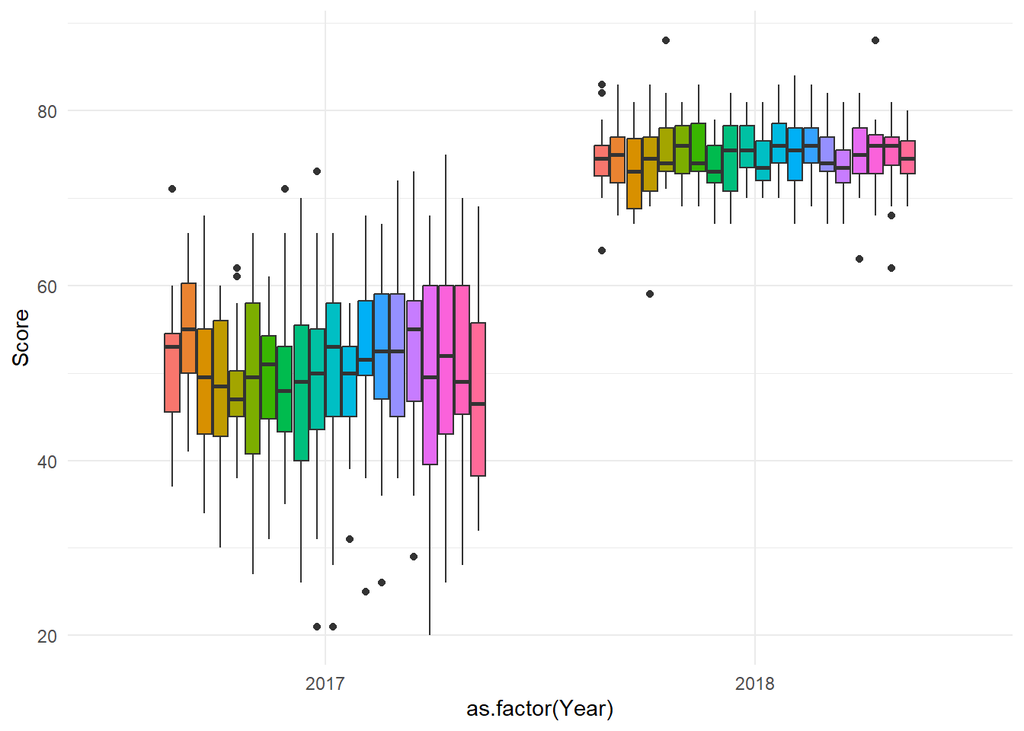

```r
ggplot(final.tidy.school) +
  geom_boxplot(aes(x=as.factor(Year),y=Score,fill=as.factor(school))) +
  guides(fill=F)+
  theme_minimal()
```

Question: If you were the district superintendent, how would you distribute the King’s ransom to these schools? In other words, how should Lebron James distribute the money to the schools. Write your answer in complete sentences below:

If Lebron James keeps his word, he should give money to schools that had the greatest meedian increase and also lowest overlap of IQRs. But personally, I dont think that the schools acted in the spirit of his mission.

### 5.2: Follow-up question about inspecting the improvement (2 Points)

Using different colors for each student, the next two pictures show the change in test scores and percentiles for all students (without missing values) sampled from the district. Both of these pictures are necessary in understanding the improvement in mathematical knowledge on the student level. As you can see, they are very different from each other. Hypothesize an educational strategy the district might have taken that would have caused this phenomenon to occur.

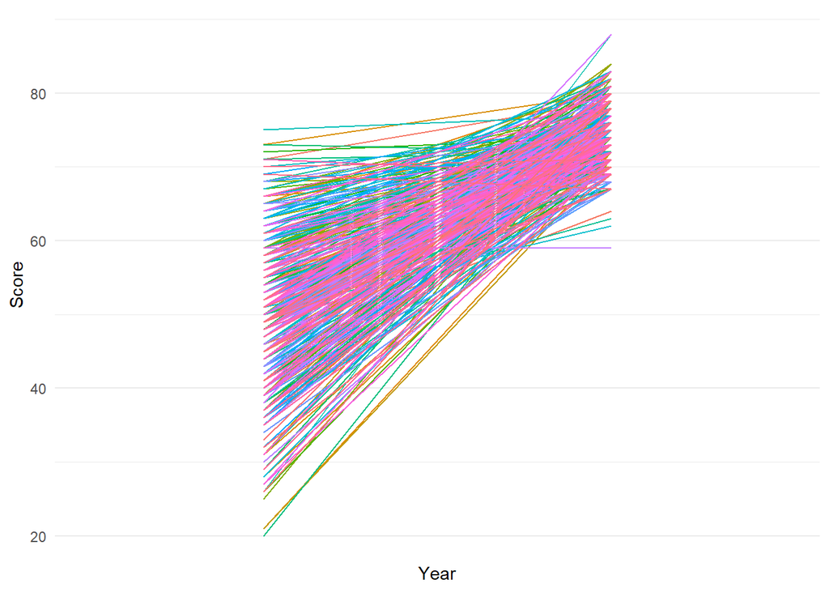

```r
ggplot(final.tidy.school) +
  geom_line(aes(x=Year,y=Score,color=as.factor(CID))) +
  guides(color=F) +
  scale_x_discrete(breaks=c(2017,2018),labels=c(2017,2018)) +
  theme_minimal()
```

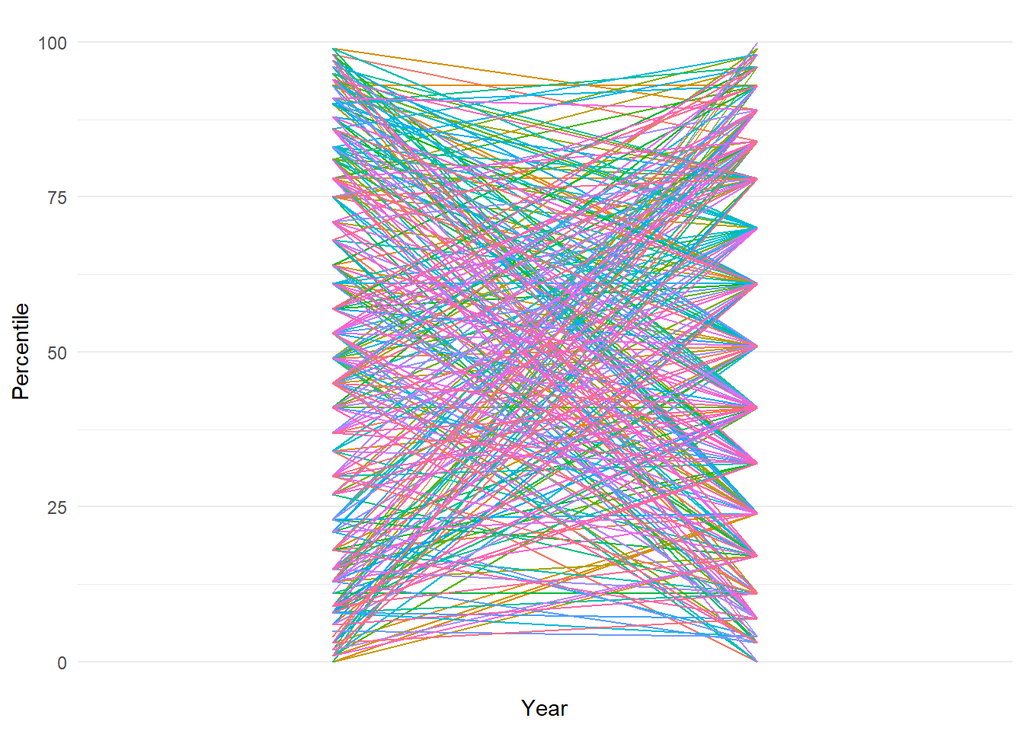

```r
ggplot(final.tidy.school) +
  geom_line(aes(x=Year,y=Percentile,color=as.factor(CID))) +
  guides(color=F) +
  scale_x_discrete(breaks=c(2017,2018),labels=c(2017,2018)) +
  theme_minimal()
```

Question: Do you believe the students actually improved in their math knowledge? Why or why not? The schools knew that they were going to get money based off the improvement of the math scores. What do we learn about the grades of the students when compared to each other. Think about this and write your answer in a well-written paragraph below:

Students scores pior to the inflation do not reflect proprtionally their percentile. That is to say, being a high percentile student one year, does not mean you will be one the next. That makes me feel that these students didn’t really learn, and students with bad grades got their sccores bumped up.

Conversly you could take this to mean that this program really did help some students and the lack of coorelation between the two years in percentiles show that there wasnt a flat grade bump. You would have to look into it more.